# Report

Josh Crisostomo

2023-03-13

## Project requirements

[Here’s the link to my repository](https://github.com/jcris74/stats220.git)  
[And here’s the link to my web page](https://jcris74.github.io/stats220/)  
I believe I expressed my creativity through making the meme and gif by creating my own template and using functions such as `image_noise()` and `image_modulation()`. And creating a gif using frames from a captivating scene and using `image_animate()` to bring it together

[figure not shown]

*Part A*

Part A had us creating a github account and repository, I had already made a github account but had never made a repository before. In this new repository we were required to edit the README.md file which contains some information about the purpose of the repo.

*Part B*

For part B were required to create a meme using R using the following functions  
- use of pipes e.g. `%>%`  
- use of named objects e.g. `meme <- image_read(url)`  
- use of comments e.g. `# note to self`  
- use of indenting and “white space”

*Part C*

For part C we were required to create an animated gif using the following functions  
- use of at least the `{r} image_animate()` function  
- creation of at least 4 different frames for the animation using a combination of different functions from the {magick} package  
- use of named objects e.g. `{r} meme <- image_read(url)`  
- use of comments e.g. `{r} # note to self`  
- use of indenting and “white space”

*Part D*

Part D was creating the html file which contained our meme, gif, descriptions for both and showing our knowledge and creativity of R, html and css by customizing our web page.

*Part E*

The final part of the practical aspect of this project was uploading the files to my github repository and finalising the website to display all my masterpieces which I have created (the meme and gif)

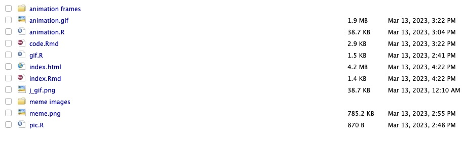

[figure not shown]

## Learning Reflection

From this project I was able to reinforce my knowledge in R and my ability to code and think logically as I have little experience in coding. Although my coding knowledge is mostly python, I was able to put to transfer the logic and coding conventions to R and use them in my project. The most important idea I learnt was to think logically, by tracing my code to know exactly what everything does and how it runs so I am able to fix any bugs that arise (I did have a few bugs which put me at a halt a few times during this project).  
I’m curious to explore further what R has to offer such as what it can do with data and displaying it, being able to visualize and communicate the data and knowing what it all means. I am also looking forward to being able to increase my skill in coding with R and my skill in thinking logically.

```css
body {
background-color: #800000
}
metadata {
background-color:#FFDEAD
}
p {
font-size: 18px;
color: #FFDEAD;
text-align: left
}
h1{
text-align: center;
background-color:#FFDEAD;
color: #191970;
padding: 20px;
margin: 20px
}
h2 {color: white;
text-align: center
}
```